# Explore red wine dataset

```
##   X fixed.acidity volatile.acidity citric.acid residual.sugar chlorides
## 1 1           7.4             0.70        0.00            1.9     0.076
## 2 2           7.8             0.88        0.00            2.6     0.098
## 3 3           7.8             0.76        0.04            2.3     0.092
## 4 4          11.2             0.28        0.56            1.9     0.075
## 5 5           7.4             0.70        0.00            1.9     0.076
## 6 6           7.4             0.66        0.00            1.8     0.075
##   free.sulfur.dioxide total.sulfur.dioxide density   pH sulphates alcohol
## 1                  11                   34  0.9978 3.51      0.56     9.4
## 2                  25                   67  0.9968 3.20      0.68     9.8
## 3                  15                   54  0.9970 3.26      0.65     9.8
## 4                  17                   60  0.9980 3.16      0.58     9.8
## 5                  11                   34  0.9978 3.51      0.56     9.4
## 6                  13                   40  0.9978 3.51      0.56     9.4
##   quality
## 1       5
## 2       5
## 3       5
## 4       6
## 5       5
## 6       5
```

> I have decided to explore red wine dataset. This tidy dataset contains 1,599 red wines with 11 variables on the chemical properties of the wine. At least 3 wine experts rated the quality of each wine, providing a rating between 0 (very bad) and 10 (very excellent).

## Univariate Plots Section

```
##  fixed.acidity   volatile.acidity  citric.acid    residual.sugar
##  Min.   : 4.60   Min.   :0.1200   Min.   :0.000   Min.   : 0.900
##  1st Qu.: 7.10   1st Qu.:0.3900   1st Qu.:0.090   1st Qu.: 1.900
##  Median : 7.90   Median :0.5200   Median :0.260   Median : 2.200
##  Mean   : 8.32   Mean   :0.5278   Mean   :0.271   Mean   : 2.539
##  3rd Qu.: 9.20   3rd Qu.:0.6400   3rd Qu.:0.420   3rd Qu.: 2.600
##  Max.   :15.90   Max.   :1.5800   Max.   :1.000   Max.   :15.500
##    chlorides       free.sulfur.dioxide total.sulfur.dioxide
##  Min.   :0.01200   Min.   : 1.00       Min.   :  6.00
##  1st Qu.:0.07000   1st Qu.: 7.00       1st Qu.: 22.00
##  Median :0.07900   Median :14.00       Median : 38.00
##  Mean   :0.08747   Mean   :15.87       Mean   : 46.47
##  3rd Qu.:0.09000   3rd Qu.:21.00       3rd Qu.: 62.00
##  Max.   :0.61100   Max.   :72.00       Max.   :289.00
##     density             pH          sulphates         alcohol
##  Min.   :0.9901   Min.   :2.740   Min.   :0.3300   Min.   : 8.40
##  1st Qu.:0.9956   1st Qu.:3.210   1st Qu.:0.5500   1st Qu.: 9.50
##  Median :0.9968   Median :3.310   Median :0.6200   Median :10.20
##  Mean   :0.9967   Mean   :3.311   Mean   :0.6581   Mean   :10.42
##  3rd Qu.:0.9978   3rd Qu.:3.400   3rd Qu.:0.7300   3rd Qu.:11.10
##  Max.   :1.0037   Max.   :4.010   Max.   :2.0000   Max.   :14.90
##     quality
##  Min.   :3.000
##  1st Qu.:5.000
##  Median :6.000
##  Mean   :5.636
##  3rd Qu.:6.000
##  Max.   :8.000
```

> Dataset contains 11 quantitative columns (all except quality) and 1 qualitative column (quality)

```
## 'data.frame':    1599 obs. of  13 variables:
##  $ fixed.acidity       : num  7.4 7.8 7.8 11.2 7.4 7.4 7.9 7.3 7.8 7.5 ...
##  $ volatile.acidity    : num  0.7 0.88 0.76 0.28 0.7 0.66 0.6 0.65 0.58 0.5 ...
##  $ citric.acid         : num  0 0 0.04 0.56 0 0 0.06 0 0.02 0.36 ...
##  $ residual.sugar      : num  1.9 2.6 2.3 1.9 1.9 1.8 1.6 1.2 2 6.1 ...
##  $ chlorides           : num  0.076 0.098 0.092 0.075 0.076 0.075 0.069 0.065 0.073 0.071 ...
##  $ free.sulfur.dioxide : num  11 25 15 17 11 13 15 15 9 17 ...
##  $ total.sulfur.dioxide: num  34 67 54 60 34 40 59 21 18 102 ...
##  $ density             : num  0.998 0.997 0.997 0.998 0.998 ...
##  $ pH                  : num  3.51 3.2 3.26 3.16 3.51 3.51 3.3 3.39 3.36 3.35 ...
##  $ sulphates           : num  0.56 0.68 0.65 0.58 0.56 0.56 0.46 0.47 0.57 0.8 ...
##  $ alcohol             : num  9.4 9.8 9.8 9.8 9.4 9.4 9.4 10 9.5 10.5 ...
##  $ quality             : int  5 5 5 6 5 5 5 7 7 5 ...
##  $ quality.factor      : Factor w/ 6 levels "3","4","5","6",..: 3 3 3 4 3 3 3 5 5 3 ...
```

I have created quality.factor which is factor of “quality” this makes sence since it’s categorical variable

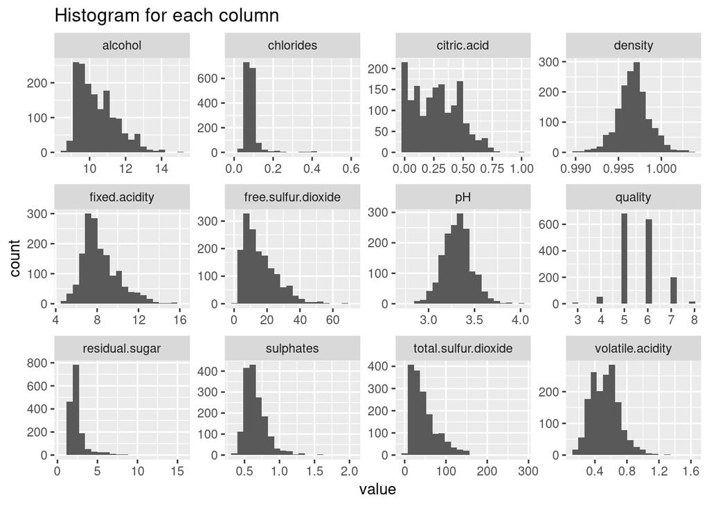

> By looking at data I see that most of the columns might have some outliers, residual.sugar, chlorides and sulfates are most visible. Alcohol, free sulfur.dioxide and total.sulfur.dioxide are clear right-skewed distribution while density and ph seem to be normally distributed. Most of the red wines are quality 5 or 6

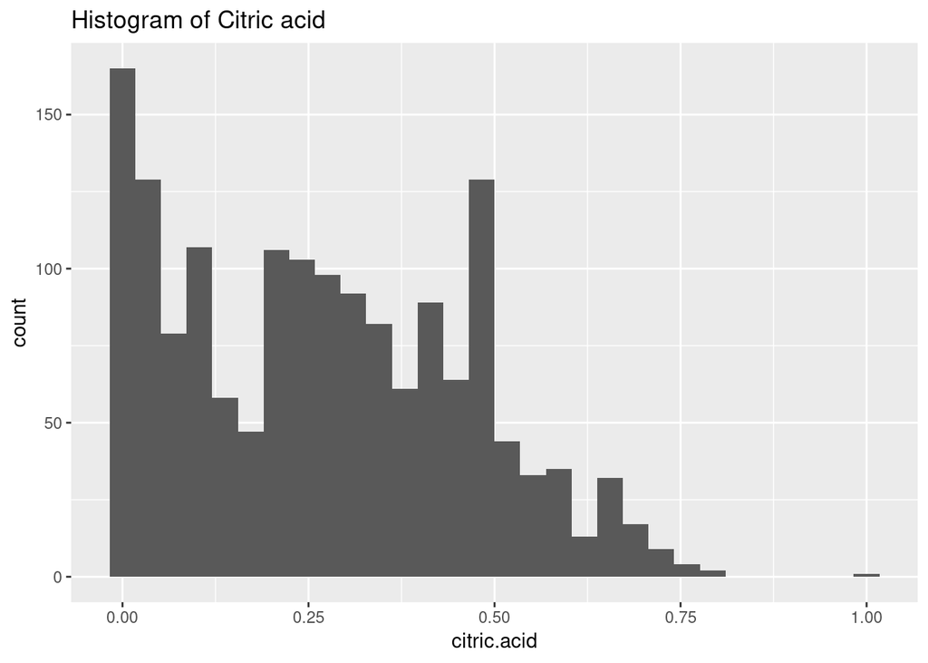

After having a closer look at citric.acid, I think it may be a good idea to split values into groups as follow 0-0.20, 0.21-0.60 and above 0.6. Distributions seem to be right skewed

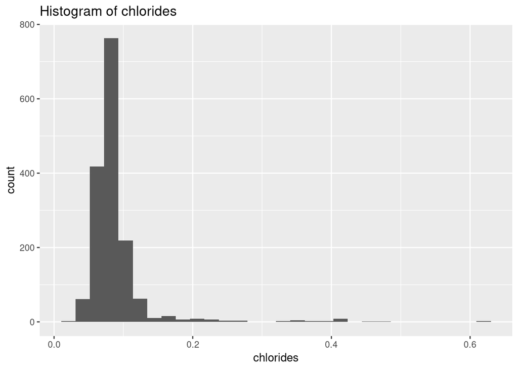

Chlorides seem to be concetrated around 0.1 mark. Threre outliers around 0.4 and 0.6

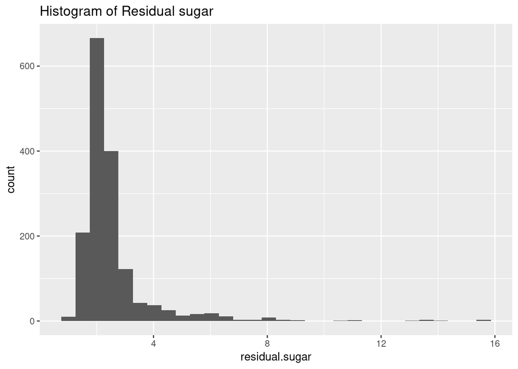

Residual sugar seem to be concentrated around 2 mark. There some ouliers from 8.

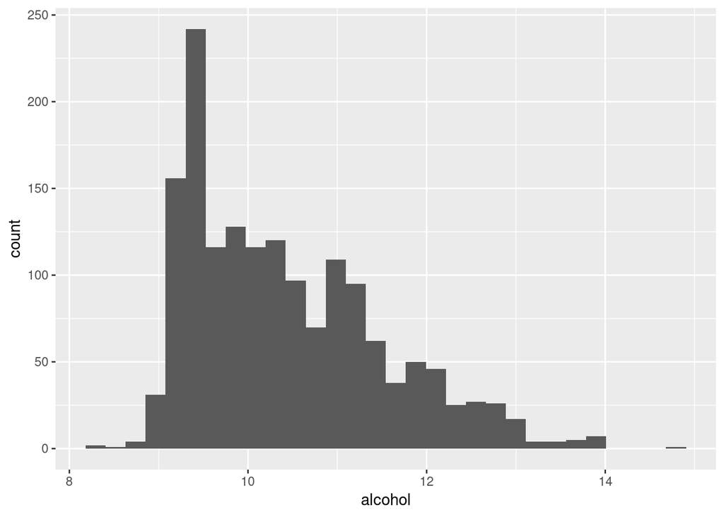

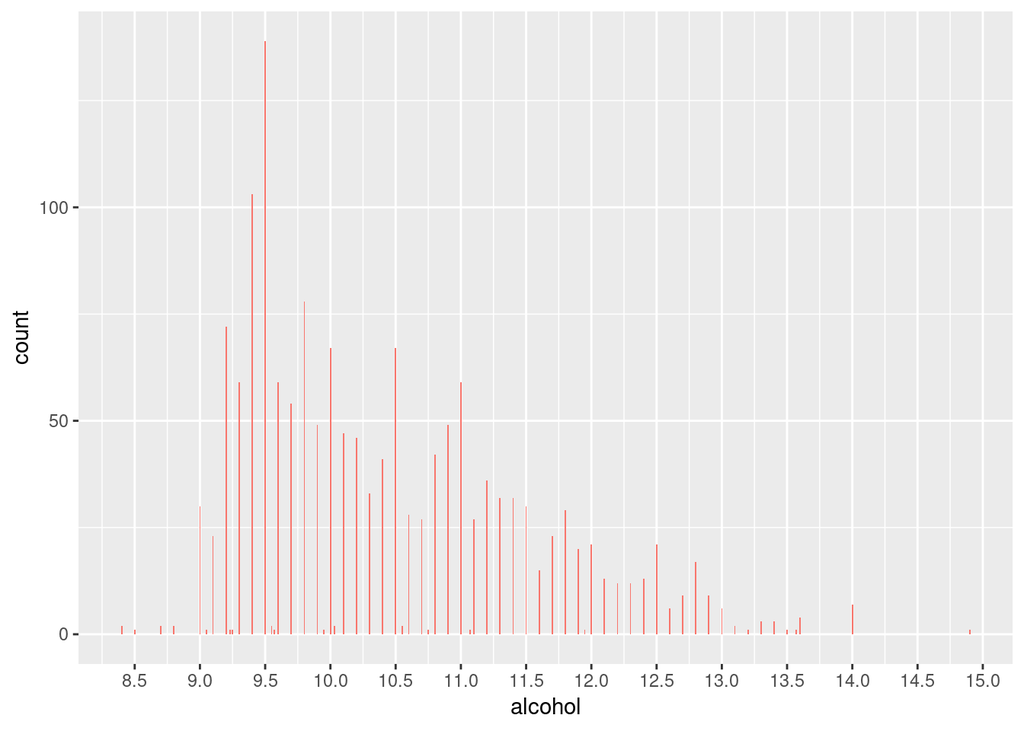

```
##    Min. 1st Qu.  Median    Mean 3rd Qu.    Max.
##    8.40    9.50   10.20   10.42   11.10   14.90
```

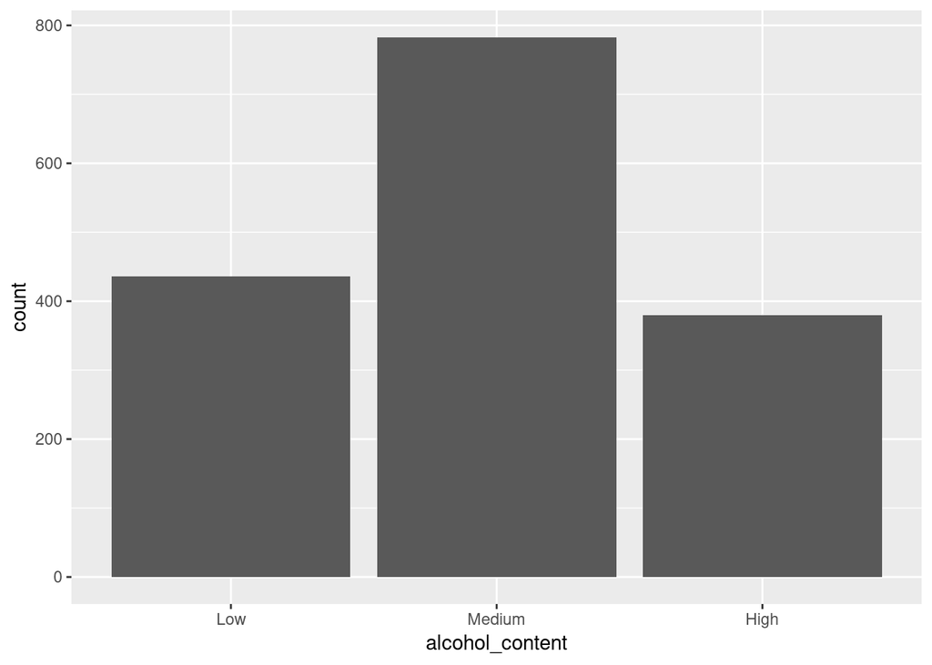

Created a new variable (alcohol_content) with low, medium, high alcohol content. There is a strict value (x=9.5%) where alcohol content is optimally chosen for wine. The count gradually decreases as content increase and immediately drops as content decreases below 9.5%. The average alcohol content is 10.42%.

# Univariate Analysis

### What is the structure of your dataset?

> There are 1599 redwine observations in the dataset with 12 features. All features contains numeric data except the quality which is a categorical.

### What is/are the main feature(s) of interest in your dataset?

> The main feature is quality

### What other features in the dataset do you think will help support your

investigation into your feature(s) of interest?

> The other feature that may support the investigation, in my opinion, are alcohol, density, ph

### Did you create any new variables from existing variables in the dataset?

> Yes, I have added “citric_acid_grouped” and I have removed “X”. Then I created alcohol_content which consists of 3 buckets (0, 9.5], (9.5, 11.1], and (11.1, 15]. Then I renamed each bucket to Low, Medium, and High to differentiate the amount of alcohol catagorically. Then I have added quality.factor to make use of category when drawing graphs

### Of the features you investigated, were there any unusual distributions?

Did you perform any operations on the data to tidy, adjust, or change the form  
of the data? If so, why did you do this? >I have noticed that citric.acid seem to be right skewed and it would fit better if in groups

# Bivariate Plots Section

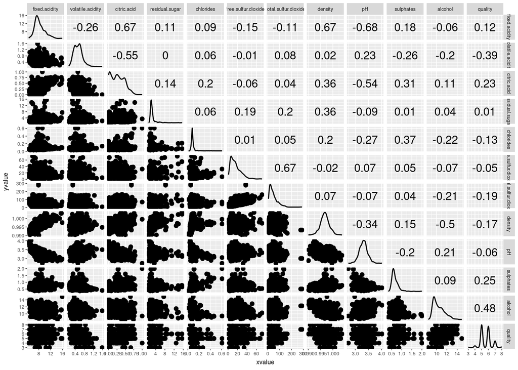

The four highest correlation coefficients with quality are:

1. alcohol at 0.48
2. sulphates at 0.25
3. citric.acid at 0.23
4. fixed.acidity at 0.12

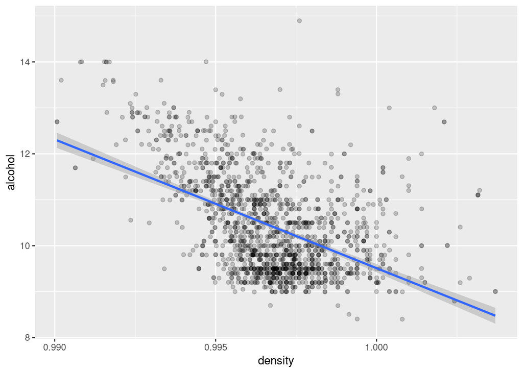

At the high and lowest points of alcohol, there is not much density. But there is a trend towards higher density as alcohol content drops.

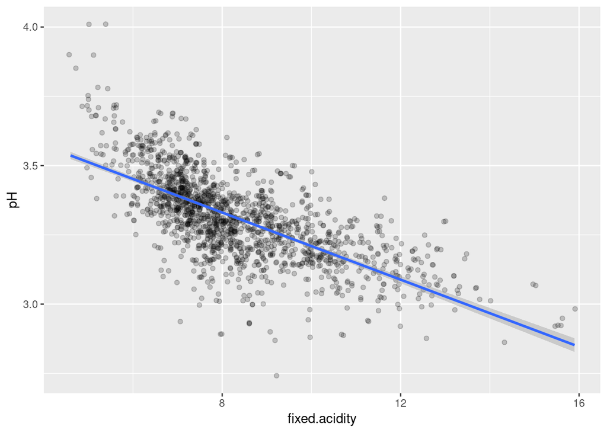

We see fixed acidity increase as pH decreases.

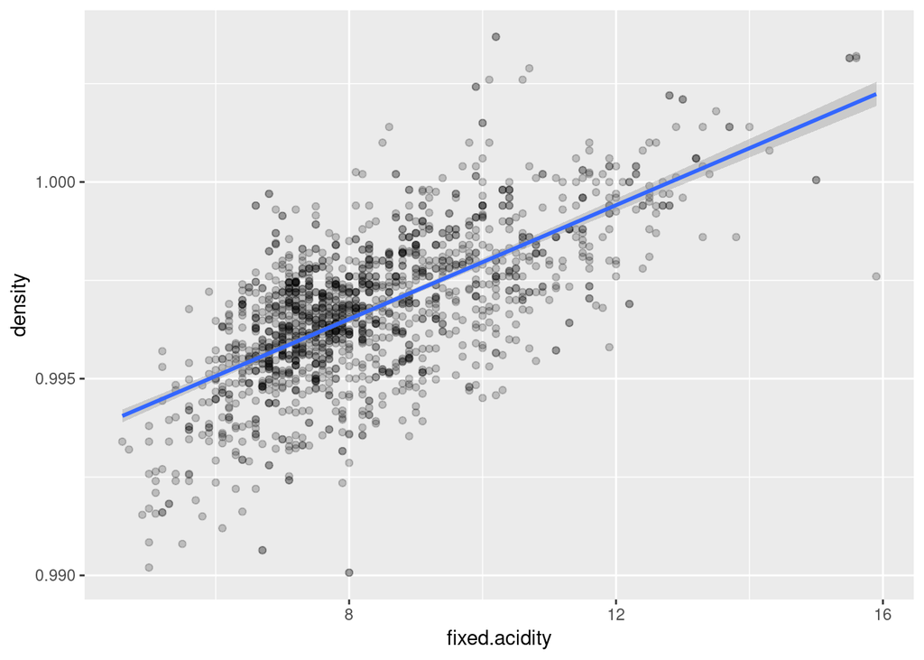

Fixed acidity increases as density increases.

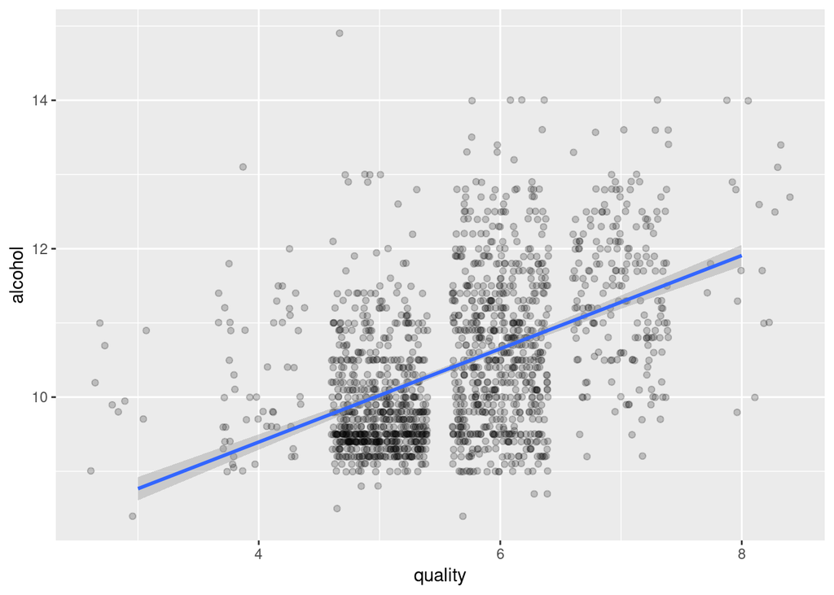

Quality seem to be incresing with higher alhocol.

# Bivariate Analysis

> Alcohol has the highest positive correlation with quality, followed by sulphates, citric.acid, and fixed.acidity. We explored this further by comparing alcohol and density. Density rises as alcohol drops. Given their negative and positive correlations, this is to be expected. It’s the same with fixed acidity and ph, which has the highest negative correlation coefficient among our fields. Density and fixed acidity correlate positively, and trend in the same direction. More density means more fixed acidity.

# Multivariate Plots Section

> **Tip**: Now it’s time to put everything together. Based on what you found in the bivariate plots section, create a few multivariate plots to investigate more complex interactions between variables. Make sure that the plots that you create here are justified by the plots you explored in the previous section. If you plan on creating any mathematical models, this is the section where you will do that.

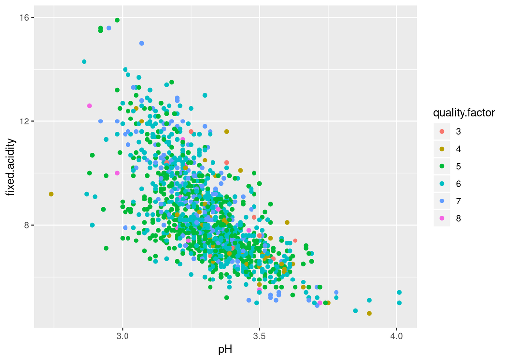

The graph shows that the higher the acidity the lower pH. We can see any relationships related to color

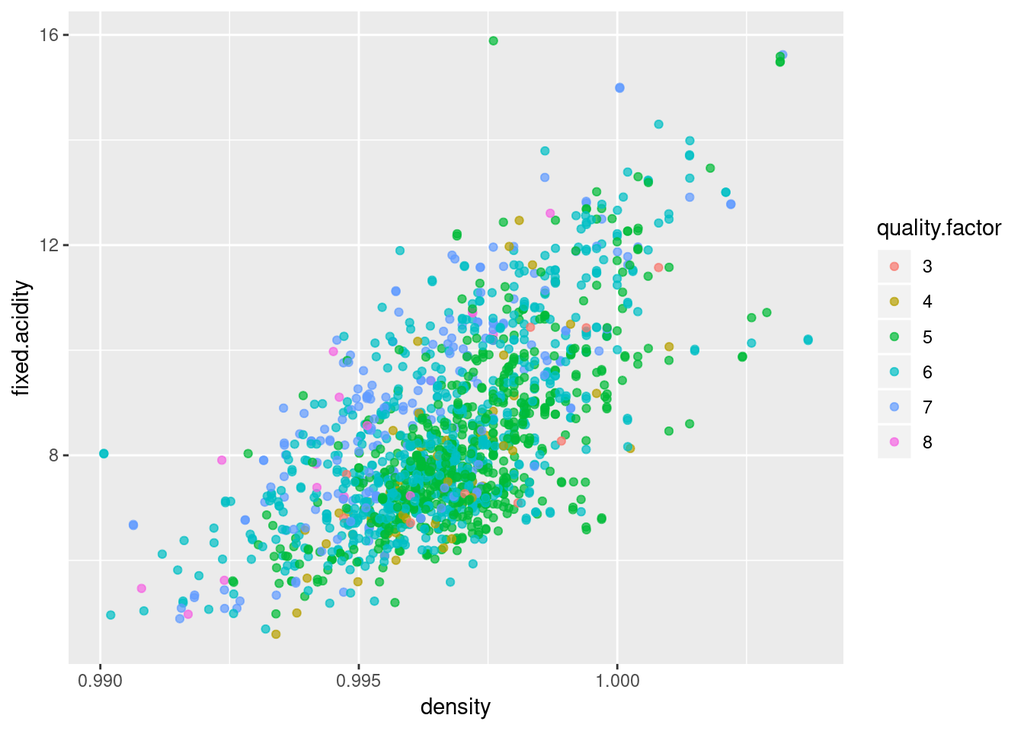

There seems to be a strong direct relationship where density increases as acidity increases. Adding quality by color shows lower quality (4 and 5) are high density and low acidity compared to (6, 7, 8).

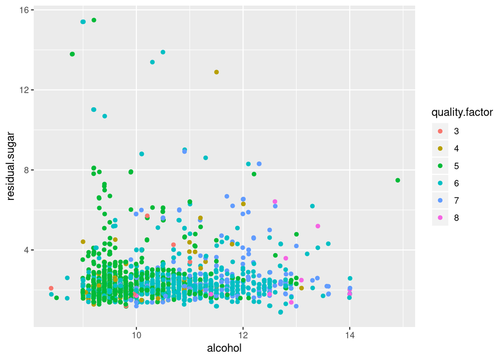

Comparing the residual sugar and alcohol shows most of the red wine is below 4 which means they would be off-dry wines and range from 9-13% in alcohol content.

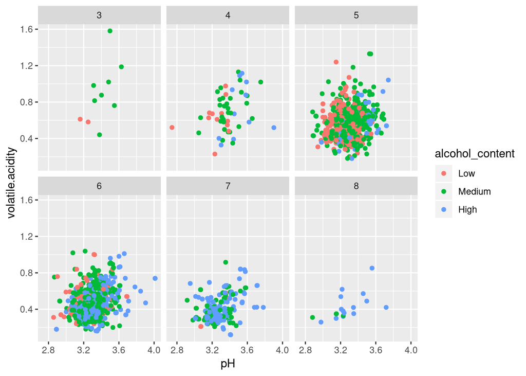

Each graph is colored by alcohol_content and seperated by quality. We see medium and high alcohol content more prominent in higher quality wines

# Multivariate Analysis

There seems to be a relationship between quality and alcohol content. Where higher quality wine usually contain more alcohol

### Were there any interesting or surprising interactions between features?

I would not say that was surprised by my finding as I would expect higher alcohol content in better wines

# Final Plots and Summary

> **Tip**: You’ve done a lot of exploration and have built up an understanding of the structure of and relationships between the variables in your dataset. Here, you will select three plots from all of your previous exploration to present here as a summary of some of your most interesting findings. Make sure that you have refined your selected plots for good titling, axis labels (with units), and good aesthetic choices (e.g. color, transparency). After each plot, make sure you justify why you chose each plot by describing what it shows.

### Plot One

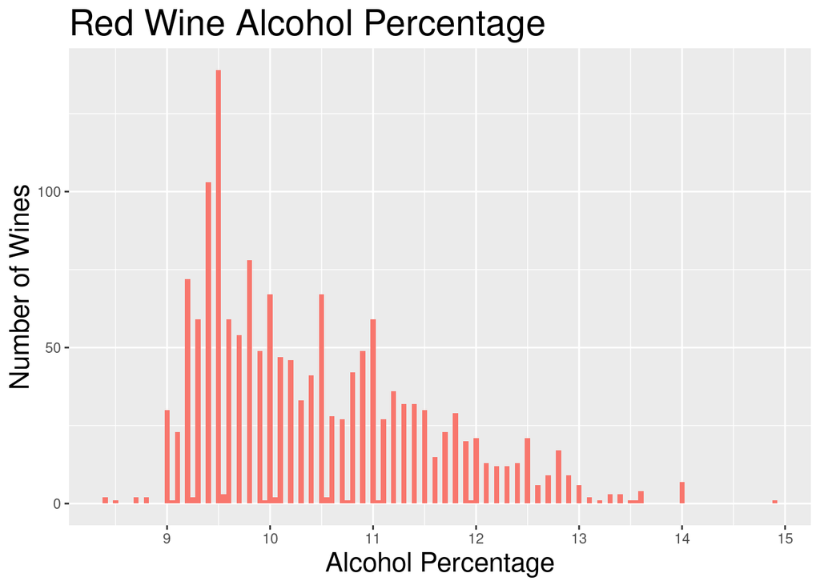

### Description One

This graph shows the greatest alcohol % to be around 9.5% and we see a gradual decrease as the % increases or decreases. This is probably becuase that’s the optimal alcohol % that is time efficient (as in the amount of time needed for fermentation) for wholesale, or the amount most consumers prefer.

### Plot Two

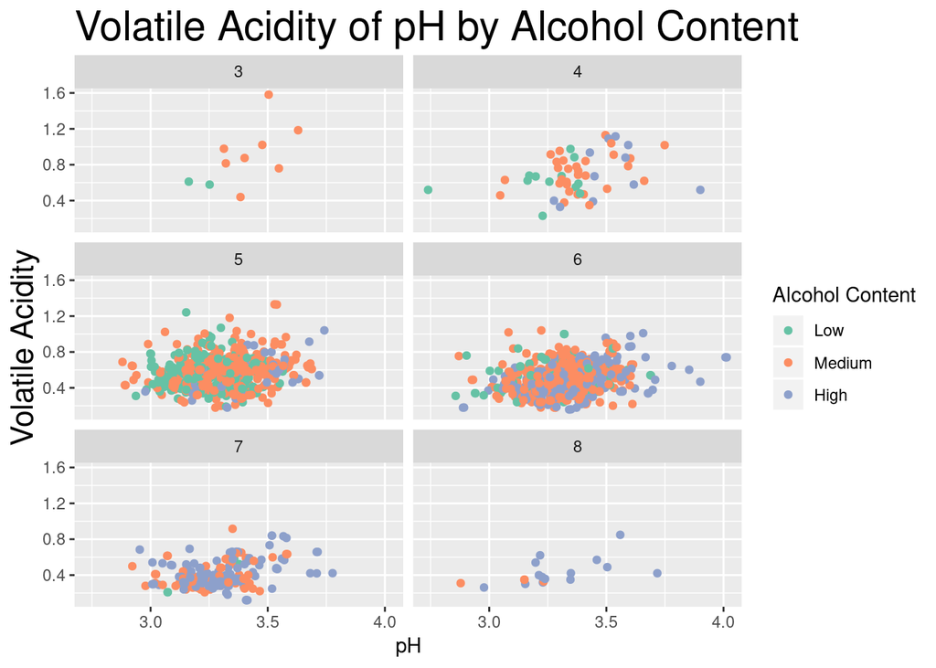

### Description Two

This plot shows how the alcohol content changes with quality, mostly high content wines are promenent in quality 8 while the opposite is true for quality 3. There is also a small down shift towards volatile acidity as quality increases, I suspect to lower the vinger taste.

### Plot Three

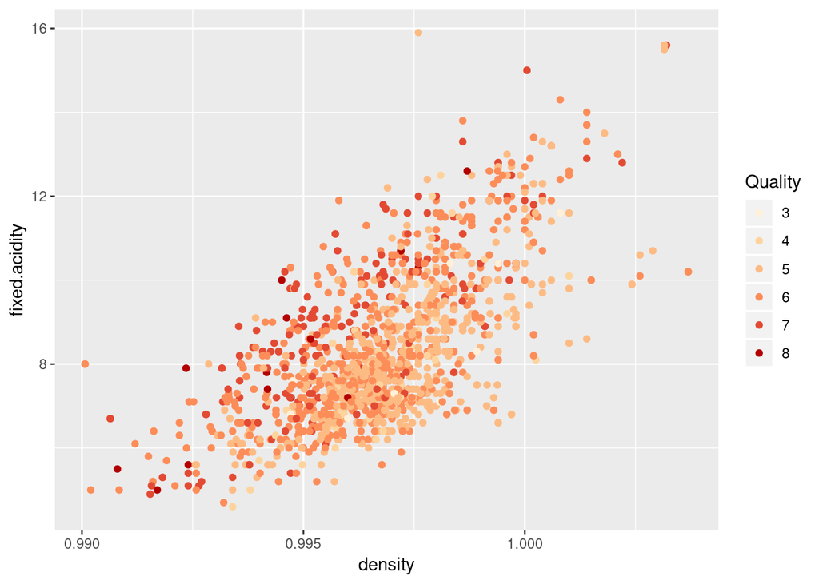

### Description Three

The graph shows how acidity increases as density increases. It is also able to determine loosely, how the higher quality is more acidic.

# Reflection

I found exploring a red wines dataset very interesting while I had a suspicion than higher quality wines generally have higher alcohol content it was a fun to explore and actually confirm that assumption. I found challenging to actually use R studio and R language, in general, I’m used to programming in Python so this was quite a challenge but at the end quite rewarding to know another programing language even on a basic level. For future, I could perhaps work out a machine learning model that would predict a price or quality of wine based on data provided